```python
%pylab inline
```

주식 데이터를 불러오기 위한 `pandas-datareader`를 설치해 주세요.

```python
!pip install -U pandas-datareader
```

# 데이터 가져오기

```python
import pandas as pd
```

```python
import pandas_datareader as pdr
```

krx 홈페이지에서 상장된 주식의 종목코드 정보를 가져옵니다.

```python
company_df = pd.read_html('http://kind.krx.co.kr/corpgeneral/corpList.do?method=download', header=0)[0]
```

```python
company_df
```

|  | 회사명 | 종목코드 | 업종 | 주요제품 | 상장일 | 결산월 | 대표자명 | 홈페이지 | 지역 |
| --- | --- | --- | --- | --- | --- | --- | --- | --- | --- |
| 0 | DSR | 155660 | 1차 비철금속 제조업 | 합섬섬유로프 | 2013-05-15 | 12월 | 홍석빈 | http://www.dsr.com | 부산광역시 |
| 1 | GS글로벌 | 1250 | 상품 종합 도매업 | 수출입업(시멘트,철강금속,전기전자,섬유,기계화학),상품중개,광업,채석업/하수처리 서... | 1976-06-26 | 12월 | 김태형 | http://www.gsgcorp.com | 서울특별시 |
| 2 | HDC현대산업개발 | 294870 | 건물 건설업 | 외주주택, 자체공사, 일반건축, 토목 등 | 2018-06-12 | 12월 | 권순호, 정경구 | http://www.hdc-dvp.com | 서울특별시 |
| 3 | KEC | 92220 | 반도체 제조업 | 반도체 제조 | 2006-10-16 | 12월 | 박남규 김학남 | http://www.kec.co.kr | 서울특별시 |
| 4 | KG동부제철 | 16380 | 1차 철강 제조업 | 철강재(냉연강판,아연도강판,칼라강판,석도강판,선재류,강관,형강,봉강),비철금속 제조,도매 | 1986-02-03 | 12월 | 박성희 | http://www.kgdongbusteel.co.kr | 서울특별시 |
| ... | ... | ... | ... | ... | ... | ... | ... | ... | ... |
| 2435 | 코셋 | 189350 | 통신 및 방송 장비 제조업 | 광통신용 증폭기 | 2013-12-24 | 12월 | 오치형, 주관종 | http://coset.com | 광주광역시 |
| 2436 | 툴젠 | 199800 | 자연과학 및 공학 연구개발업 | 유전자가위 (유전체 교정 도구) 및 이를 이용한 유전자세포치료제, 고부가가치 가축,... | 2014-06-25 | 12월 | 김영호, 이병화(각자 대표이사) | http://www.toolgen.com | 서울특별시 |
| 2437 | 플럼라인생명과학 | 222670 | 자연과학 및 공학 연구개발업 | 강아지암치료제,돼지DNA테라피 | 2015-07-28 | 12월 | 김앤토니경태 | http://www.plsdna.com | 서울특별시 |
| 2438 | 한국미라클피플사 | 331660 | 기타 화학제품 제조업 | 은나노스텝, 닥터오렌지 등 | 2019-10-28 | 12월 | 이호경 | http://www.kmpc.co.kr | 경기도 |
| 2439 | 휴벡셀 | 212310 | 의료용 기기 제조업 | 척추용 임플란트 등 | 2016-07-26 | 12월 | 박정민, 허성규(각자대표) | http://huvexel.com | 경기도 |

2440 rows × 9 columns

울산광역시 상장회사 목록을 한 번 볼까요?

```python
company_df[ company_df['지역']=='울산광역시' ]
```

|  | 회사명 | 종목코드 | 업종 | 주요제품 | 상장일 | 결산월 | 대표자명 | 홈페이지 | 지역 |
| --- | --- | --- | --- | --- | --- | --- | --- | --- | --- |
| 5 | KG케미칼 | 1390 | 기초 화학물질 제조업 | 콘크리트혼화제, 비료, 친환경농자재, 수처리제 | 1989-08-25 | 12월 | 곽정현, 김재익 | http://www.kgchem.co.kr | 울산광역시 |
| 311 | 덕양산업 | 24900 | 자동차 신품 부품 제조업 | 자동차부품(CRASH PAD,TRIM PANEL) 제조,판매 | 1997-06-23 | 12월 | 윤성희, 손동인, 한상욱(각자대표이사) | http://www.duckyang.co.kr | 울산광역시 |
| 315 | 디티알오토모티브 | 7340 | 일차전지 및 축전지 제조업 | 자동차용 밧데리 | 1988-09-24 | 12월 | 김상헌 김원종 | http://www.x-probattery.co.kr | 울산광역시 |
| 359 | 큐로 | 15590 | 일반 목적용 기계 제조업 | 열교환기,압력용기,저장탱크,산업용보일러 제조 | 1989-05-27 | 12월 | 서상훈 | http://www.curo.co.kr | 울산광역시 |
| 367 | 한국프랜지공업 | 10100 | 자동차 신품 부품 제조업 | 자동차부품(제동,구동장치),프랜지(관이음쇠),철구조물,산업기계 제조 | 1987-10-02 | 12월 | 이현덕 | http://www.kofco.com | 울산광역시 |
| 543 | 클리노믹스 | 352770 | 의료용품 및 기타 의약 관련제품 제조업 | Geno Series, CD-PRIME, Cancer Prime | 2020-12-04 | 12월 | 김병철,정종태 | http://www.clinomics.com | 울산광역시 |
| 632 | 롯데정밀화학 | 4000 | 기초 화학물질 제조업 | 염소·셀룰로스계열, 암모니아 계열, 전자재료 등 화학제품 제조 | 1976-04-15 | 12월 | 정경문 | http://www.lottefinechem.com | 울산광역시 |
| 639 | 미원화학 | 134380 | 기타 화학제품 제조업 | 계면활성제, 황산및분황 | 2011-02-15 | 12월 | 정규식 | http://www.miwonchemicals.com | 울산광역시 |
| 655 | 센트랄모텍 | 308170 | 자동차 신품 부품 제조업 | 이너레이스, 오디 클러치보스, 로터샤프트, 슬리브기어, 컨트롤 암, 엑슬 | 2019-11-25 | 12월 | 이종철, 강태룡 | http://www.centralmotek.co.kr | 울산광역시 |
| 656 | 송원산업 | 4430 | 기타 화학제품 제조업 | 폴리머첨가제(PVC안정제,산화방지제),폴리우레탄수지,프라스틱첨가제 제조 | 1977-06-25 | 12월 | 김충식 대표이사 | http://www.songwon.com | 울산광역시 |
| 681 | 진양화학 | 51630 | 플라스틱제품 제조업 | 레쟈,바닥재 제조 | 2001-01-29 | 12월 | 김상용 | http://www.chinyang.co.kr | 울산광역시 |
| 812 | 에이팸 | 73070 | 자동차 신품 부품 제조업 | 자동차용 와이어링 하네스 | 2004-01-28 | 12월 | 남상은 | http://www.nexentech.co.kr | 울산광역시 |
| 815 | 엔브이에이치코리아 | 67570 | 자동차 신품 부품 제조업 | 헤드라이너, NVH부품 | 2013-12-03 | 12월 | 곽정용,구자겸(각자 대표이사) | http://www.nvh-korea.co.kr | 울산광역시 |
| 936 | 디아이씨 | 92200 | 자동차 신품 부품 제조업 | 자동차부품(트란스밋숀,프런트액슬,기어,전동축),변속동력전달장치,특수공구,농기계 및 ... | 2007-10-18 | 12월 | 김정렬 | http://dicorp.co.kr | 울산광역시 |
| 958 | 세진중공업 | 75580 | 선박 및 보트 건조업 | 선박 Deck House, LPG Tank, Upper Deck Unit, 해양플랜... | 2015-11-30 | 12월 | 최양환 | http://www.sejinheavy.com | 울산광역시 |
| 1039 | 덕산하이메탈 | 77360 | 반도체 제조업 | 솔더볼(Solderball) | 2005-10-14 | 12월 | 김윤철, 김길연 (각자 대표이사) | http://www.hi-metal.co.kr | 울산광역시 |
| 1157 | 코엔텍 | 29960 | 폐기물 처리업 | 산업폐기물 소각/매립처리 | 2004-06-18 | 12월 | 이민석 | http://www.koentec.co.kr | 울산광역시 |
| 1407 | 에이치엘비 | 28300 | 선박 및 보트 건조업 | 각종 산업용 밸브류, 제지·제철용기계,기타 특수목적용 산업기계 | 1996-07-27 | 12월 | 진양곤, 김동건 (각자대표) | http://www.hlbkorea.com | 울산광역시 |
| 1413 | 에코캡 | 128540 | 자동차 신품 부품 제조업 | 자동차 부품(전선, 케이블, 벌브소켓, LED 등) | 2018-12-05 | 12월 | 최영천 | http://www.ecocab.co.kr | 울산광역시 |
| 1455 | 제이씨케미칼 | 137950 | 기타 화학제품 제조업 | 바이오디젤, 글리세린 등 | 2011-08-08 | 12월 | 윤사호, 이종응 | http://www.jcchemical.co.kr | 울산광역시 |
| 1529 | 경동도시가스 | 267290 | 연료용 가스 제조 및 배관공급업 | 도시가스 | 2017-05-12 | 12월 | 송재호, 나윤호 | http://www.kdgas.co.kr | 울산광역시 |
| 1564 | 세종공업 | 33530 | 자동차 신품 부품 제조업 | 자동차부품,자동차소음기(머플러),배기가스정화기,배기계통부품 제조 | 2002-09-25 | 12월 | 박정길, 김기홍, 김익석 (각자 대표이사) | http://www.sjku.co.kr | 울산광역시 |
| 1773 | 현대공업 | 170030 | 자동차 신품 부품 제조업 | 시트패드, 암레스트, 헤드레스트 | 2013-12-04 | 12월 | 강현석 | http://www.hdi21.co.kr | 울산광역시 |
| 1841 | 무림P&P | 9580 | 펄프, 종이 및 판지 제조업 | 표백화학펄프(B.K.P) 제조,목재가공,조림사업 | 1989-06-20 | 12월 | 이도균 | http://www.moorimpnp.co.kr | 울산광역시 |
| 2036 | 일진파워 | 94820 | 전기 및 통신 공사업 | 열교환기,압력용기 | 2007-11-06 | 12월 | 이광섭 | http://ijeng.com | 울산광역시 |
| 2207 | 현대미포조선 | 10620 | 선박 및 보트 건조업 | 선박수리,선박개조,선박신조 | 1983-12-20 | 12월 | 신현대 | http://www.hmd.co.kr | 울산광역시 |

상장회사의 종목코드는 여섯자리로 구성되어야 하는데, pandas에서 숫자로 인식하여 앞에 0들을 날려버리네요.

올바른 종목코드를 조회하는 함수를 만들어 보겠습니다.

```python
def get_code(company_name):
    code = company_df[company_df['회사명']==company_name]['종목코드']
    code = str(code.values[0])
    if len(code) <6:
        code = '0'+code
    if len(code) <6:
        code = '0'+code
    return code+".KS"
```

```python
get_code("덕양산업")
```

```
'024900.KS'
```

이제 이 종목의 정보를 야후에서 조회해 보겠습니다.

```python
df = pdr.DataReader(get_code("덕양산업"), 'yahoo')
```

```python
df
```

| Date | High | Low | Open | Close | Volume | Adj Close |
| --- | --- | --- | --- | --- | --- | --- |
| 2016-04-11 | 1940.0 | 1875.0 | 1915.0 | 1915.0 | 121437.0 | 1884.112915 |
| 2016-04-12 | 1940.0 | 1900.0 | 1940.0 | 1915.0 | 28787.0 | 1884.112915 |
| 2016-04-14 | 1950.0 | 1895.0 | 1950.0 | 1910.0 | 32320.0 | 1879.193604 |
| 2016-04-15 | 1930.0 | 1900.0 | 1905.0 | 1930.0 | 37184.0 | 1898.870972 |
| 2016-04-18 | 1985.0 | 1925.0 | 1950.0 | 1975.0 | 137777.0 | 1943.145142 |
| ... | ... | ... | ... | ... | ... | ... |
| 2021-04-05 | 3150.0 | 3025.0 | 3095.0 | 3140.0 | 413941.0 | 3140.000000 |
| 2021-04-06 | 3180.0 | 3010.0 | 3180.0 | 3015.0 | 309418.0 | 3015.000000 |
| 2021-04-07 | 3040.0 | 2940.0 | 3000.0 | 2980.0 | 275546.0 | 2980.000000 |
| 2021-04-08 | 3770.0 | 2895.0 | 2955.0 | 3275.0 | 14703773.0 | 3275.000000 |
| 2021-04-09 | 3335.0 | 3150.0 | 3335.0 | 3225.0 | 1210662.0 | 3225.000000 |

1221 rows × 6 columns

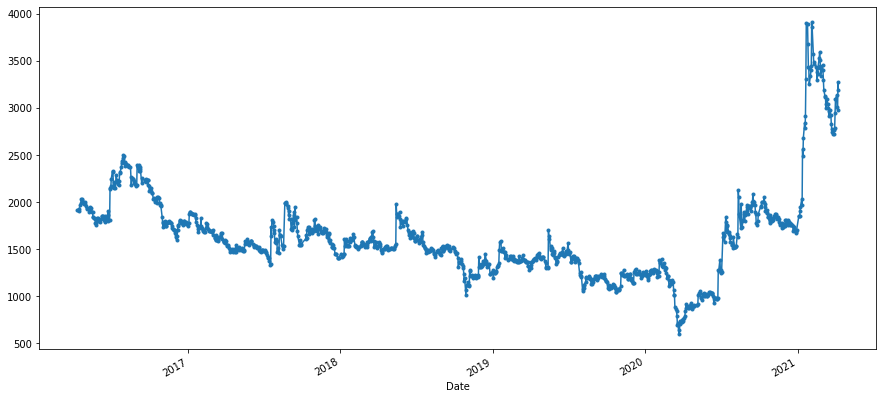

```python
plt.figure(figsize=(15, 7))
df['Close'].plot(style='.-');
```

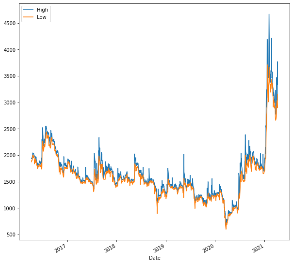

```python
plt.figure(figsize=(10, 10))
df['High'].plot(label='High');
df['Low'].plot(label='Low');
plt.legend();
```

총 1221일치의 정보가 있네요.

# 학습 데이터 준비하기

주식 데이터를 10일치 씩 잘라서 9일 간 데이터는 학습하고,

10일 째의 값이 9일째 값에서의 상승, 하락을 1, 0으로 만들어 보겠습니다.

```python
range(0, df.shape[0], 10)
```

```
range(0, 1221, 10)
```

```python
list(range(0, df.shape[0], 10))
```

```
[0,
 10,
 20,
 30,
 40,
 50,
 60,
 70,
 80,
 90,
 100,
 110,
 120,
 130,
 140,
 150,
 160,
 170,
 180,
 190,
 200,
 210,
 220,
 230,
 240,
 250,
 260,
 270,
 280,
 290,
 300,
 310,
 320,
 330,
 340,
 350,
 360,
 370,
 380,
 390,
```

[output cut: 68 more lines]

```
 1080,
 1090,
 1100,
 1110,
 1120,
 1130,
 1140,
 1150,
 1160,
 1170,
 1180,
 1190,
 1200,
 1210,
 1220]
```

```python
dataset = []
for i in list(range(0, df.shape[0], 10)):
    if i == 0:
        continue
    dataset.append(
        df.iloc[i:i+10]
    )
```

```python
dataset
```

```
[              High     Low    Open   Close   Volume    Adj Close
 Date
 2016-04-26  2020.0  1950.0  2005.0  1980.0  95902.0  1948.064575
 2016-04-27  2020.0  1975.0  2000.0  1995.0  60642.0  1962.822632
 2016-04-28  2030.0  1985.0  2000.0  2005.0  59902.0  1972.661377
 2016-04-29  2010.0  1975.0  2010.0  1980.0  50381.0  1948.064575
 2016-05-02  1990.0  1940.0  1990.0  1955.0  36598.0  1923.467773
 2016-05-03  1990.0  1835.0  1990.0  1940.0  90269.0  1908.709717
 2016-05-04  1970.0  1910.0  1970.0  1930.0  37081.0  1898.870972
 2016-05-09  1965.0  1875.0  1965.0  1900.0  60994.0  1869.354858
 2016-05-10  1940.0  1860.0  1900.0  1915.0  18049.0  1884.112915
 2016-05-11  1970.0  1930.0  1970.0  1945.0  26682.0  1913.629028,
               High     Low    Open   Close    Volume    Adj Close
 Date
 2016-05-12  1975.0  1895.0  1975.0  1935.0   18700.0  1903.790405
 2016-05-13  1940.0  1900.0  1920.0  1935.0   38043.0  1903.790405
 2016-05-16  1965.0  1895.0  1950.0  1900.0   50725.0  1869.354858
 2016-05-17  1920.0  1880.0  1880.0  1895.0   38437.0  1864.435547
 2016-05-18  1915.0  1840.0  1895.0  1840.0  166422.0  1810.322632
 2016-05-19  1880.0  1820.0  1845.0  1840.0   45968.0  1810.322632
 2016-05-20  1865.0  1810.0  1865.0  1835.0   27458.0  1805.403198
 2016-05-23  1865.0  1805.0  1865.0  1820.0   35721.0  1790.645142
 2016-05-24  1840.0  1775.0  1800.0  1780.0   80376.0  1751.290405
 2016-05-25  1795.0  1750.0  1780.0  1760.0  109135.0  1731.612915,
               High     Low    Open   Close   Volume    Adj Close
 Date
 2016-05-26  1780.0  1755.0  1760.0  1780.0  42963.0  1751.290405
 2016-05-27  1845.0  1785.0  1790.0  1830.0  75014.0  1800.483887
 2016-05-30  1850.0  1820.0  1830.0  1830.0  56675.0  1800.483887
 2016-05-31  1835.0  1810.0  1835.0  1810.0  26391.0  1780.806519
 2016-06-01  1830.0  1775.0  1810.0  1800.0  82012.0  1770.967773
 2016-06-02  1810.0  1780.0  1810.0  1800.0  12043.0  1770.967773
 2016-06-03  1815.0  1785.0  1815.0  1785.0  31483.0  1756.209717
 2016-06-07  1845.0  1780.0  1780.0  1820.0  51712.0  1790.645142
 2016-06-08  1870.0  1820.0  1820.0  1850.0  51278.0  1820.161377
 2016-06-09  1895.0  1820.0  1870.0  1855.0  61487.0  1825.080688,
               High     Low    Open   Close    Volume    Adj Close
 Date
 2016-06-10  1865.0  1830.0  1830.0  1850.0   29434.0  1820.161377
 2016-06-13  1880.0  1830.0  1880.0  1830.0   50555.0  1800.483887
```

[output cut: 1400 more lines]

```
               High     Low    Open   Close      Volume  Adj Close
 Date
 2021-03-26  2820.0  2660.0  2750.0  2725.0    280220.0     2725.0
 2021-03-29  2775.0  2685.0  2700.0  2720.0    327379.0     2720.0
 2021-03-30  2780.0  2700.0  2700.0  2765.0    186763.0     2765.0
 2021-03-31  2885.0  2720.0  2775.0  2785.0    397687.0     2785.0
 2021-04-01  3050.0  2770.0  2840.0  2945.0   1371072.0     2945.0
 2021-04-02  3470.0  2945.0  2945.0  3095.0   3045182.0     3095.0
 2021-04-05  3150.0  3025.0  3095.0  3140.0    413941.0     3140.0
 2021-04-06  3180.0  3010.0  3180.0  3015.0    309418.0     3015.0
 2021-04-07  3040.0  2940.0  3000.0  2980.0    275546.0     2980.0
 2021-04-08  3770.0  2895.0  2955.0  3275.0  14703773.0     3275.0,
               High     Low    Open   Close     Volume  Adj Close
 Date
 2021-04-09  3335.0  3150.0  3335.0  3225.0  1210662.0     3225.0]
```

각각의 값을 X, Y로 구성해 보겠습니다.

```python
X = []
Y = []
for d in dataset[:-1]:
    close = d['Close'].values
    X.append(close[:9])

    # 정답을 만들자
    if close[9] > close[8]:
        y = 1
    else:
        y = 0
    Y.append(
        np.array([y])
    )

X = np.array(X)
Y = np.array(Y)
```

데이터에 대해 가볍게 조사를 해볼까요?

```python
import seaborn as sns
```

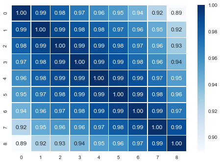

```python
sns.heatmap(data = pd.DataFrame(X).corr(),
            annot=True,
            fmt = '.2f',
            linewidths=.5,
            cmap='Blues');
```

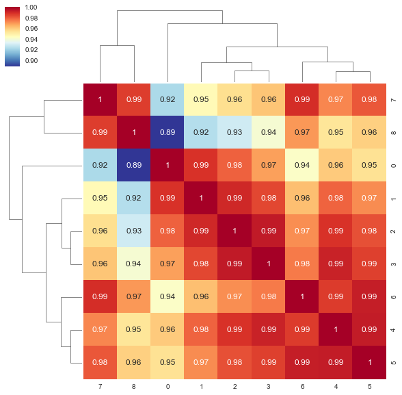

```python
sns.clustermap(pd.DataFrame(X).corr(),
               annot=True,
               cmap='RdYlBu_r'
              );
```

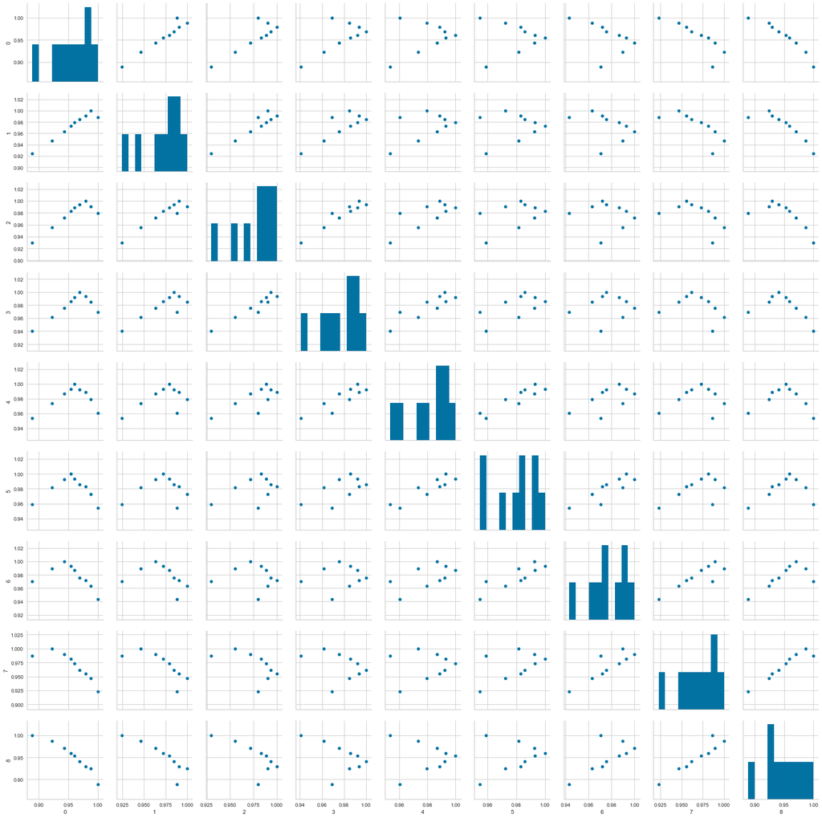

```python
sns.pairplot(pd.DataFrame(X).corr())
```

# 딥러닝 학습하기

```python
from keras.models import Sequential
from keras.layers import Dense
from tqdm.keras import TqdmCallback
```

```python
model = Sequential()
model.add(Dense(18, input_dim=9, activation='relu'))
model.add(Dense(9, activation='relu'))
model.add(Dense(1, activation='sigmoid'))
model.compile(loss='binary_crossentropy' , optimizer='adam', metrics=['accuracy'])
```

학습을 진행합니다.

```python
history = model.fit(X, Y,
                    epochs=150,
                    verbose=0,
                    callbacks=[TqdmCallback(verbose=0)]
                   )
```

그림을 그려보죠.

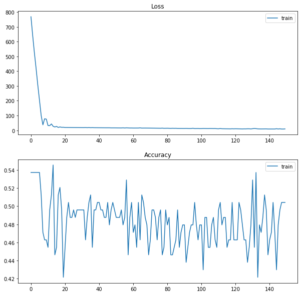

```python
plt.figure(figsize=(10, 10))

plt.subplot(211)
plt.title('Loss')
plt.plot(history.history['loss'], label='train')
# plt.plot(history.history['val_loss'], label='test')
plt.legend()

plt.subplot(212)
plt.title('Accuracy')
plt.plot(history.history['accuracy'], label='train')
# plt.plot(history.history['val_accuracy'], label='test')
plt.legend()
```

더 학습을 진행해 보겠습니다.

```python
history = model.fit(X, Y,
                    epochs=10000,
                    verbose=0,
                    callbacks=[TqdmCallback(verbose=0)]
                   )
```

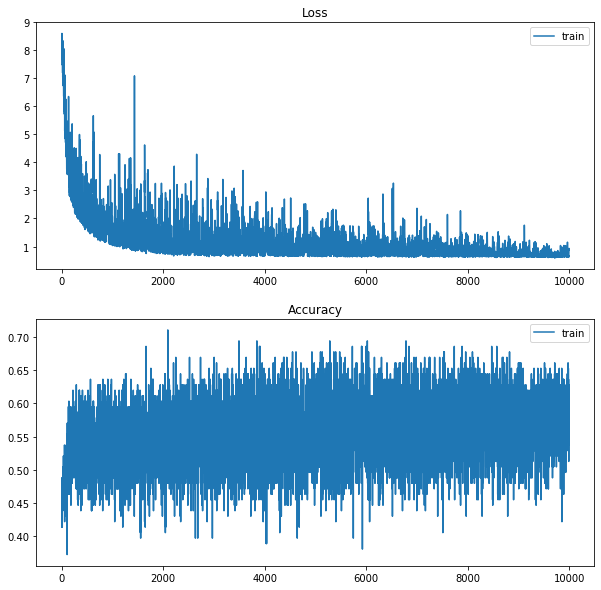

```python
plt.figure(figsize=(10, 10))

plt.subplot(211)
plt.title('Loss')
plt.plot(history.history['loss'], label='train')
# plt.plot(history.history['val_loss'], label='test')
plt.legend()

plt.subplot(212)
plt.title('Accuracy')
plt.plot(history.history['accuracy'], label='train')
# plt.plot(history.history['val_accuracy'], label='test')
plt.legend()
```

선이 아닌 점으로 찍어보겠습니다.

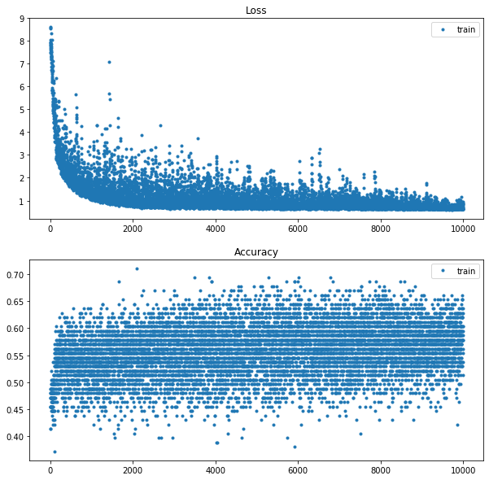

```python
plt.figure(figsize=(10, 10))

plt.subplot(211)
plt.title('Loss')
plt.plot(history.history['loss'], '.', label='train')
# plt.plot(history.history['val_loss'], label='test')
plt.legend()

plt.subplot(212)
plt.title('Accuracy')
plt.plot(history.history['accuracy'], '.', label='train')
# plt.plot(history.history['val_accuracy'], label='test')
plt.legend()
```

오늘 주식 값을 잘 예측하는지 입력해 보겠습니다.

```python
df[-10:-1]
```

| Date | High | Low | Open | Close | Volume | Adj Close |
| --- | --- | --- | --- | --- | --- | --- |
| 2021-03-29 | 2775.0 | 2685.0 | 2700.0 | 2720.0 | 327379.0 | 2720.0 |
| 2021-03-30 | 2780.0 | 2700.0 | 2700.0 | 2765.0 | 186763.0 | 2765.0 |
| 2021-03-31 | 2885.0 | 2720.0 | 2775.0 | 2785.0 | 397687.0 | 2785.0 |
| 2021-04-01 | 3050.0 | 2770.0 | 2840.0 | 2945.0 | 1371072.0 | 2945.0 |
| 2021-04-02 | 3470.0 | 2945.0 | 2945.0 | 3095.0 | 3045182.0 | 3095.0 |
| 2021-04-05 | 3150.0 | 3025.0 | 3095.0 | 3140.0 | 413941.0 | 3140.0 |
| 2021-04-06 | 3180.0 | 3010.0 | 3180.0 | 3015.0 | 309418.0 | 3015.0 |
| 2021-04-07 | 3040.0 | 2940.0 | 3000.0 | 2980.0 | 275546.0 | 2980.0 |
| 2021-04-08 | 3770.0 | 2895.0 | 2955.0 | 3275.0 | 14703773.0 | 3275.0 |

```python
df[-1:]
```

| Date | High | Low | Open | Close | Volume | Adj Close |
| --- | --- | --- | --- | --- | --- | --- |
| 2021-04-09 | 3335.0 | 3150.0 | 3335.0 | 3225.0 | 1210662.0 | 3225.0 |

아래와 같이 입력하여 지난 9일 간의 종가 데이터를 넣어 봅니다.

```python
df[-10:-1]['Close'].values
```

```
array([2720., 2765., 2785., 2945., 3095., 3140., 3015., 2980., 3275.])
```

```python
model.predict(
    np.array([
        df[-10:-1]['Close'].values
    ])
)
```

```
array([[0.8869981]], dtype=float32)
```

1에 가까우니 오른다고 예측이 되었네요.. ㅠ

설계를 변경해서도 해보겠습니다.

```python
model = Sequential()
model.add(Dense(48, input_dim=9, activation='relu'))
model.add(Dense(12, activation='relu'))
model.add(Dense(24, activation='relu'))
model.add(Dense(6, activation='relu'))
model.add(Dense(1, activation='sigmoid'))
model.compile(loss='binary_crossentropy' , optimizer='adam', metrics=['accuracy'])
```

```python
history_2 = model.fit(X, Y,
                    epochs=10000,
                    verbose=0,
                    callbacks=[TqdmCallback(verbose=0)]
                   )
```

# PyCaret

이번에는 어제 해봤던 AutoML을 이용해서 예측해 보겠습니다.

데이터를 먼저 준비합니다.

X와 Y가 같이 붙어 있어야 합니다.

```python
X
```

```
array([[1980., 1995., 2005., ..., 1930., 1900., 1915.],
       [1935., 1935., 1900., ..., 1835., 1820., 1780.],
       [1780., 1830., 1830., ..., 1785., 1820., 1850.],
       ...,
       [3445., 3345., 3455., ..., 3120., 3125., 3000.],
       [3095., 3040., 3000., ..., 2925., 2830., 2775.],
       [2725., 2720., 2765., ..., 3140., 3015., 2980.]])
```

```python
Y
```

```
array([[1],
       [0],
       [1],
       [1],
       [1],
       [1],
       [1],
       [1],
       [0],
       [0],
       [0],
       [0],
       [1],
       [1],
       [0],
       [1],
       [0],
       [0],
       [0],
       [1],
       [0],
       [0],
       [0],
       [0],
       [1],
       [1],
       [1],
       [0],
       [0],
       [0],
       [0],
       [0],
       [1],
       [1],
       [0],
       [1],
       [0],
       [1],
       [0],
       [0],
```

[output cut: 66 more lines]

```
       [1],
       [0],
       [0],
       [1],
       [0],
       [0],
       [1],
       [1],
       [1],
       [0],
       [0],
       [0],
       [1],
       [0],
       [1]])
```

```python
dataset = pd.DataFrame(
    np.column_stack(
        [ pd.DataFrame(X), Y ]
    ),
    columns=[1, 2, 3, 4, 5, 6, 7, 8, 9, 'result']
)
```

하나로 잘 합쳐졌습니다.

```python
dataset
```

|  | 1 | 2 | 3 | 4 | 5 | 6 | 7 | 8 | 9 | result |
| --- | --- | --- | --- | --- | --- | --- | --- | --- | --- | --- |
| 0 | 1980.0 | 1995.0 | 2005.0 | 1980.0 | 1955.0 | 1940.0 | 1930.0 | 1900.0 | 1915.0 | 1.0 |
| 1 | 1935.0 | 1935.0 | 1900.0 | 1895.0 | 1840.0 | 1840.0 | 1835.0 | 1820.0 | 1780.0 | 0.0 |
| 2 | 1780.0 | 1830.0 | 1830.0 | 1810.0 | 1800.0 | 1800.0 | 1785.0 | 1820.0 | 1850.0 | 1.0 |
| 3 | 1850.0 | 1830.0 | 1815.0 | 1850.0 | 1795.0 | 1800.0 | 1825.0 | 1830.0 | 1860.0 | 1.0 |
| 4 | 1800.0 | 1810.0 | 2150.0 | 2145.0 | 2170.0 | 2250.0 | 2335.0 | 2325.0 | 2165.0 | 1.0 |
| ... | ... | ... | ... | ... | ... | ... | ... | ... | ... | ... |
| 116 | 3680.0 | 3440.0 | 3430.0 | 3250.0 | 3340.0 | 3400.0 | 3445.0 | 3910.0 | 3860.0 | 0.0 |
| 117 | 3470.0 | 3485.0 | 3440.0 | 3380.0 | 3295.0 | 3365.0 | 3430.0 | 3530.0 | 3595.0 | 0.0 |
| 118 | 3445.0 | 3345.0 | 3455.0 | 3400.0 | 3300.0 | 3195.0 | 3120.0 | 3125.0 | 3000.0 | 1.0 |
| 119 | 3095.0 | 3040.0 | 3000.0 | 2915.0 | 2965.0 | 2975.0 | 2925.0 | 2830.0 | 2775.0 | 0.0 |
| 120 | 2725.0 | 2720.0 | 2765.0 | 2785.0 | 2945.0 | 3095.0 | 3140.0 | 3015.0 | 2980.0 | 1.0 |

121 rows × 10 columns

이제 pycaret으로 분류를 해보겠습니다.

```python
from pycaret.classification import *
```

```python
exp_01 = setup(data = dataset,
                target = 'result',
#                 numeric_features=["임신횟수"],
                train_size = 0.8,
                normalize=True,
                session_id=123)
```

|  | Description | Value |
| --- | --- | --- |
| 0 | session_id | 123 |
| 1 | Target | result |
| 2 | Target Type | Binary |
| 3 | Label Encoded | 0.0: 0, 1.0: 1 |
| 4 | Original Data | (121, 10) |
| 5 | Missing Values | False |
| 6 | Numeric Features | 9 |
| 7 | Categorical Features | 0 |
| 8 | Ordinal Features | False |
| 9 | High Cardinality Features | False |
| 10 | High Cardinality Method | None |
| 11 | Transformed Train Set | (96, 8) |
| 12 | Transformed Test Set | (25, 8) |
| 13 | Shuffle Train-Test | True |
| 14 | Stratify Train-Test | False |
| 15 | Fold Generator | StratifiedKFold |
| 16 | Fold Number | 10 |
| 17 | CPU Jobs | -1 |
| 18 | Use GPU | False |
| 19 | Log Experiment | False |
| 20 | Experiment Name | clf-default-name |
| 21 | USI | 17c6 |
| 22 | Imputation Type | simple |
| 23 | Iterative Imputation Iteration | None |
| 24 | Numeric Imputer | mean |
| 25 | Iterative Imputation Numeric Model | None |
| 26 | Categorical Imputer | constant |
| 27 | Iterative Imputation Categorical Model | None |
| 28 | Unknown Categoricals Handling | least_frequent |
| 29 | Normalize | True |
| 30 | Normalize Method | zscore |
| 31 | Transformation | False |
| 32 | Transformation Method | None |
| 33 | PCA | False |
| 34 | PCA Method | None |
| 35 | PCA Components | None |
| 36 | Ignore Low Variance | False |
| 37 | Combine Rare Levels | False |
| 38 | Rare Level Threshold | None |
| 39 | Numeric Binning | False |
| 40 | Remove Outliers | False |
| 41 | Outliers Threshold | None |
| 42 | Remove Multicollinearity | False |
| 43 | Multicollinearity Threshold | None |
| 44 | Clustering | False |
| 45 | Clustering Iteration | None |
| 46 | Polynomial Features | False |
| 47 | Polynomial Degree | None |
| 48 | Trignometry Features | False |
| 49 | Polynomial Threshold | None |
| 50 | Group Features | False |
| 51 | Feature Selection | False |
| 52 | Feature Selection Method | classic |
| 53 | Features Selection Threshold | None |
| 54 | Feature Interaction | False |
| 55 | Feature Ratio | False |
| 56 | Interaction Threshold | None |
| 57 | Fix Imbalance | False |
| 58 | Fix Imbalance Method | SMOTE |

```python
compare_models(sort = "AUC")
```

|  | Model | Accuracy | AUC | Recall | Prec. | F1 | Kappa | MCC | TT (Sec) |
| --- | --- | --- | --- | --- | --- | --- | --- | --- | --- |
| lr | Logistic Regression | 0.5311 | 0.5305 | 0.2050 | 0.4167 | 0.2650 | 0.0161 | 0.0137 | 0.6110 |
| nb | Naive Bayes | 0.5278 | 0.4862 | 0.8200 | 0.4927 | 0.6106 | 0.0966 | 0.1289 | 0.1920 |
| lda | Linear Discriminant Analysis | 0.5644 | 0.4763 | 0.3550 | 0.4833 | 0.4021 | 0.1046 | 0.0997 | 0.0210 |
| et | Extra Trees Classifier | 0.5100 | 0.4753 | 0.3600 | 0.4255 | 0.3684 | -0.0095 | -0.0023 | 0.1080 |
| knn | K Neighbors Classifier | 0.4722 | 0.4665 | 0.3450 | 0.3667 | 0.3499 | -0.0846 | -0.1006 | 0.2730 |
| qda | Quadratic Discriminant Analysis | 0.4567 | 0.4627 | 0.7000 | 0.4477 | 0.5382 | -0.0424 | -0.0803 | 0.0150 |
| ada | Ada Boost Classifier | 0.4800 | 0.4571 | 0.4500 | 0.4370 | 0.4106 | -0.0512 | -0.0557 | 0.0240 |
| dt | Decision Tree Classifier | 0.4467 | 0.4358 | 0.3550 | 0.3655 | 0.3543 | -0.1278 | -0.1336 | 0.1880 |
| catboost | CatBoost Classifier | 0.4300 | 0.4280 | 0.3000 | 0.3950 | 0.3197 | -0.1579 | -0.1508 | 0.4430 |
| rf | Random Forest Classifier | 0.4100 | 0.3917 | 0.3200 | 0.3783 | 0.3210 | -0.1954 | -0.1899 | 0.1200 |
| xgboost | Extreme Gradient Boosting | 0.4267 | 0.3808 | 0.3300 | 0.3288 | 0.3197 | -0.1634 | -0.1657 | 0.0740 |
| gbc | Gradient Boosting Classifier | 0.4078 | 0.3715 | 0.3600 | 0.3050 | 0.3261 | -0.2035 | -0.2183 | 0.0240 |
| lightgbm | Light Gradient Boosting Machine | 0.4578 | 0.3218 | 0.1350 | 0.1650 | 0.1436 | -0.1383 | -0.1578 | 0.0260 |
| svm | SVM - Linear Kernel | 0.5100 | 0.0000 | 0.4900 | 0.4680 | 0.4324 | 0.0123 | 0.0162 | 0.1990 |
| ridge | Ridge Classifier | 0.5322 | 0.0000 | 0.2450 | 0.4167 | 0.3060 | 0.0237 | 0.0186 | 0.1900 |

```
LogisticRegression(C=1.0, class_weight=None, dual=False, fit_intercept=True,
                   intercept_scaling=1, l1_ratio=None, max_iter=1000,
                   multi_class='auto', n_jobs=None, penalty='l2',
                   random_state=123, solver='lbfgs', tol=0.0001, verbose=0,
                   warm_start=False)
```

```python
model = create_model('nb')
```

|  | Accuracy | AUC | Recall | Prec. | F1 | Kappa | MCC |
| --- | --- | --- | --- | --- | --- | --- | --- |
| 0 | 0.6000 | 0.4583 | 1.0000 | 0.5000 | 0.6667 | 0.2857 | 0.4082 |
| 1 | 0.6000 | 0.5833 | 0.7500 | 0.5000 | 0.6000 | 0.2308 | 0.2500 |
| 2 | 0.7000 | 0.5600 | 1.0000 | 0.6250 | 0.7692 | 0.4000 | 0.5000 |
| 3 | 0.5000 | 0.6400 | 0.8000 | 0.5000 | 0.6154 | 0.0000 | 0.0000 |
| 4 | 0.7000 | 0.7200 | 0.8000 | 0.6667 | 0.7273 | 0.4000 | 0.4082 |
| 5 | 0.4000 | 0.4000 | 0.6000 | 0.4286 | 0.5000 | -0.2000 | -0.2182 |
| 6 | 0.4444 | 0.3500 | 1.0000 | 0.4444 | 0.6154 | 0.0000 | 0.0000 |
| 7 | 0.4444 | 0.6000 | 0.7500 | 0.4286 | 0.5455 | -0.0465 | -0.0598 |
| 8 | 0.3333 | 0.2000 | 0.5000 | 0.3333 | 0.4000 | -0.2857 | -0.3162 |
| 9 | 0.5556 | 0.3500 | 1.0000 | 0.5000 | 0.6667 | 0.1818 | 0.3162 |
| Mean | 0.5278 | 0.4862 | 0.8200 | 0.4927 | 0.6106 | 0.0966 | 0.1289 |
| SD | 0.1180 | 0.1528 | 0.1706 | 0.0916 | 0.1030 | 0.2277 | 0.2704 |

```python
tuned_model = tune_model(model, optimize = "Recall", n_iter = 500)
```

|  | Accuracy | AUC | Recall | Prec. | F1 | Kappa | MCC |
| --- | --- | --- | --- | --- | --- | --- | --- |
| 0 | 0.6000 | 0.4583 | 1.0000 | 0.5000 | 0.6667 | 0.2857 | 0.4082 |
| 1 | 0.6000 | 0.5833 | 0.7500 | 0.5000 | 0.6000 | 0.2308 | 0.2500 |
| 2 | 0.7000 | 0.5600 | 1.0000 | 0.6250 | 0.7692 | 0.4000 | 0.5000 |
| 3 | 0.5000 | 0.6400 | 0.8000 | 0.5000 | 0.6154 | 0.0000 | 0.0000 |
| 4 | 0.7000 | 0.7200 | 0.8000 | 0.6667 | 0.7273 | 0.4000 | 0.4082 |
| 5 | 0.4000 | 0.4000 | 0.6000 | 0.4286 | 0.5000 | -0.2000 | -0.2182 |
| 6 | 0.4444 | 0.3500 | 1.0000 | 0.4444 | 0.6154 | 0.0000 | 0.0000 |
| 7 | 0.4444 | 0.6000 | 0.7500 | 0.4286 | 0.5455 | -0.0465 | -0.0598 |
| 8 | 0.3333 | 0.2000 | 0.5000 | 0.3333 | 0.4000 | -0.2857 | -0.3162 |
| 9 | 0.5556 | 0.3500 | 1.0000 | 0.5000 | 0.6667 | 0.1818 | 0.3162 |
| Mean | 0.5278 | 0.4862 | 0.8200 | 0.4927 | 0.6106 | 0.0966 | 0.1289 |
| SD | 0.1180 | 0.1528 | 0.1706 | 0.0916 | 0.1030 | 0.2277 | 0.2704 |

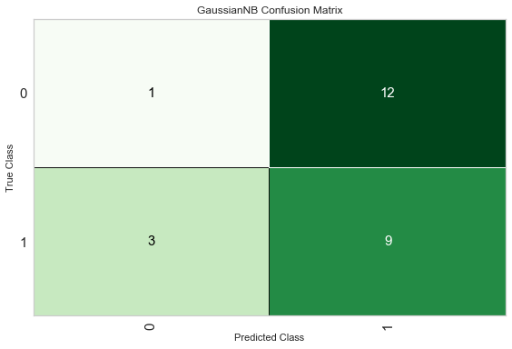

```python
plot_model(tuned_model, plot = 'confusion_matrix')
```

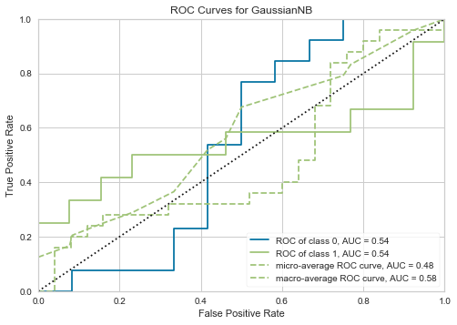

```python
plot_model(tuned_model, plot = 'auc')
```

```python
predict_model(tuned_model)
```

|  | Model | Accuracy | AUC | Recall | Prec. | F1 | Kappa | MCC |
| --- | --- | --- | --- | --- | --- | --- | --- | --- |
| 0 | Naive Bayes | 0.4000 | 0.5449 | 0.7500 | 0.4286 | 0.5455 | -0.1682 | -0.2359 |

|  | 1 | 2 | 4 | 5 | 6 | 7 | 8 | 9 | result | Label | Score |
| --- | --- | --- | --- | --- | --- | --- | --- | --- | --- | --- | --- |
| 0 | 0.329393 | 0.356700 | 1.058941 | 1.089631 | 1.253222 | 1.398355 | 1.294064 | 0.949300 | 1.0 | 0.0 | 0.7021 |
| 1 | -0.768514 | -0.896370 | -0.856110 | -0.949087 | -1.063701 | -1.006272 | -0.965010 | -0.910142 | 1.0 | 1.0 | 0.5994 |
| 2 | 0.129773 | -0.047516 | -0.289832 | -0.204955 | -0.240584 | -0.247967 | -0.350617 | -0.378873 | 1.0 | 1.0 | 0.8142 |
| 3 | 0.828442 | 0.498175 | 0.719174 | 0.345499 | 0.216703 | 0.360673 | 0.490628 | 0.408871 | 0.0 | 1.0 | 0.6939 |
| 4 | 0.079869 | -0.108149 | -0.135392 | -0.092825 | -0.332042 | -0.247967 | -0.331713 | 0.115757 | 0.0 | 1.0 | 0.8081 |
| 5 | -0.289427 | -0.279941 | -0.300128 | -0.327278 | -0.271070 | -0.287878 | -0.322261 | -0.314754 | 1.0 | 1.0 | 0.8087 |
| 6 | -0.908248 | -0.845843 | -0.804630 | -0.887926 | -0.931596 | -0.946406 | -0.936653 | -0.919301 | 0.0 | 1.0 | 0.6109 |
| 7 | -0.868324 | -0.866054 | -0.876702 | -0.857345 | -0.850301 | -0.866584 | -0.823227 | -0.772744 | 0.0 | 1.0 | 0.6484 |
| 8 | 0.329393 | 0.255646 | 0.338223 | 0.345499 | 0.338647 | 0.270874 | 0.254323 | 0.253154 | 0.0 | 1.0 | 0.7669 |
| 9 | -0.169656 | -0.168781 | -0.166280 | -0.164181 | -0.047507 | 0.031409 | -0.048147 | 0.115757 | 1.0 | 1.0 | 0.8073 |
| 10 | 0.688708 | 0.609335 | 0.472070 | 0.559564 | 0.389456 | 0.380629 | 0.140897 | 0.106597 | 1.0 | 1.0 | 0.7389 |
| 11 | 1.227681 | 1.245975 | 1.223676 | 1.130406 | 1.100793 | 1.099023 | 1.029403 | 1.379811 | 0.0 | 0.0 | 0.8322 |
| 12 | 1.038042 | 1.043867 | 1.357524 | 1.222148 | 1.202412 | 1.118979 | 1.029403 | 1.068377 | 1.0 | 0.0 | 0.7663 |
| 13 | 0.688708 | 0.730600 | 0.719174 | 0.651307 | 0.623181 | 0.590160 | 0.490628 | 0.491309 | 1.0 | 1.0 | 0.6407 |
| 14 | 0.229583 | 0.336489 | 0.245559 | 0.233370 | 0.287837 | 0.310785 | 0.273227 | 0.262314 | 1.0 | 1.0 | 0.7702 |
| 15 | -0.499028 | -0.522470 | -0.536935 | -0.541343 | -0.535280 | -0.547298 | -0.596374 | -0.598708 | 0.0 | 1.0 | 0.7652 |
| 16 | -0.758533 | -0.704368 | -0.794334 | -0.806377 | -0.799491 | -0.776785 | -0.728705 | -0.699466 | 0.0 | 1.0 | 0.6959 |
| 17 | 0.329393 | 0.336489 | 0.389703 | 0.396467 | 0.247189 | 0.151141 | 0.018018 | 0.069958 | 0.0 | 1.0 | 0.7841 |
| 18 | -1.838475 | -2.084765 | -1.904240 | -1.823697 | -1.836009 | -1.816462 | -1.675815 | -1.666742 | 1.0 | 0.0 | 0.9687 |
| 19 | 0.538993 | 0.680073 | 0.945685 | 0.773630 | 0.745125 | 0.679960 | 0.490628 | 0.427191 | 0.0 | 1.0 | 0.6267 |
| 20 | -0.309389 | -0.290046 | -0.300128 | -0.296697 | -0.332042 | -0.347744 | -0.388426 | -0.415512 | 0.0 | 1.0 | 0.8042 |
| 21 | 0.399260 | 0.376910 | 0.399999 | 0.304725 | 0.247189 | 0.280852 | 0.235419 | 0.234835 | 0.0 | 1.0 | 0.7655 |
| 22 | -0.918229 | -0.876159 | -0.804630 | -0.745215 | -0.738519 | -0.706941 | -0.671992 | -0.708626 | 0.0 | 1.0 | 0.6808 |
| 23 | -0.359294 | -0.431522 | -0.320720 | -0.317084 | -0.301556 | -0.287878 | -0.303356 | -0.351393 | 1.0 | 1.0 | 0.8029 |
| 24 | 0.010002 | 0.023221 | -0.063320 | -0.133600 | -0.057669 | -0.088323 | -0.123765 | -0.030800 | 1.0 | 1.0 | 0.8154 |

```python
final_model = finalize_model(tuned_model)
```

```python
final_model.predict(
    np.array([
        df[-9:-1]['Close'].values
    ])
)
```

```
array([0])
```